# Дискретные предикторы в линейных моделях

## Мы рассмотрим

- Линейные модели c непрерывными и дискретными предикторами

## Влияет ли стаж работы на предприятиях, вырабатывающих кадмий, на жизненнй объем легких?

Пример взят из книги: P. Armitage and G. Berry (1987), Statistical Methods in Medical Research, 2nd ed., Blackwell, p.286.

Данные представлены в пакете `ISwR`

Переменные:

`group` - Группа 1: Более 10 лет в отрасли; Группа 2 - менее 10 лет; Группа 3 - не подвергались воздействию.

`age` - возраст

`vital.capacity` - объем легких (л).

## Загружаем данные

```r
vit <- read.table("data/vitcap2.csv", header = TRUE, sep = ";")
```

## Немного преобразуем исходный датасет

```r
vit$Group [vit$group == 1] <- "Long exposed"
vit$Group [vit$group == 2] <- "Short exposed"
vit$Group [vit$group == 3] <- "Not exposed"
```

## Меняем порядок уровней

```r
vit$Group <- factor(vit$Group, levels = c("Not exposed", "Short exposed", "Long exposed"))

levels(vit$Group)
```

```
## [1] "Not exposed"   "Short exposed" "Long exposed"
```

## Вычисляем средние

```r
library(dplyr)
vit_summary <- vit %>%  group_by(Group) %>%  #Передаем датафрейм группирующей функции
            summarise(mean_capac = mean(vital.capacity),  # Вычисляем среднюю
            SD_capac = sd(vital.capacity), # Стандартное отклонение
            n_capac = n(),  # объем выборки
            SE_capac = sd(vital.capacity)/sqrt(n())) # Стандартную ошибку

vit_summary
```

```
## # A tibble: 3 × 5
##           Group mean_capac SD_capac n_capac SE_capac
##          <fctr>      <dbl>    <dbl>   <int>    <dbl>
## 1   Not exposed       4.46    0.692      44    0.104
## 2 Short exposed       4.47    0.682      28    0.129
## 3  Long exposed       3.95    1.033      12    0.298
```

## Визуализируем результаты

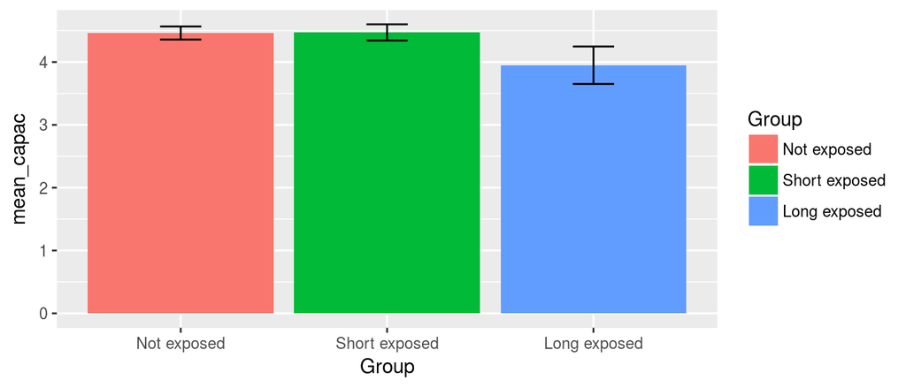

```r
library(ggplot2)
ggplot(vit_summary, aes(x = Group, y = mean_capac)) +  geom_bar(stat = "identity", aes(fill = Group)) + geom_errorbar(aes(ymin = mean_capac - SE_capac, ymax = mean_capac + SE_capac), width = 0.2)
```

## Модели с дискретными предикторами

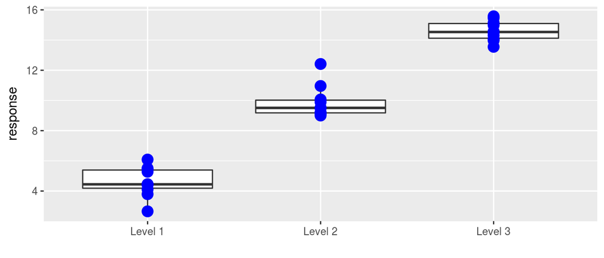

Модель имеет такой вид  
\(response = 4.6 + 5.3I_{Level2} + 9.9 I_{Level3} + \epsilon_i\)

\(I_{i}\) - dummy variable

Моделями с дискретными предикторами занимается классический **дисперсионный анализ**

## Модель с дискретным предиктором

```r
M1 <- lm(vital.capacity ~ Group, data = vit)
anova(M1)
```

```
## Analysis of Variance Table
##
## Response: vital.capacity
##           Df Sum Sq Mean Sq F value Pr(>F)
## Group      2    2.7   1.374    2.48   0.09 .
## Residuals 81   44.9   0.554
## ---
## Signif. codes:  0 '***' 0.001 '**' 0.01 '*' 0.05 '.' 0.1 ' ' 1
```

В принципе можно было бы обсуждать результат.

## Смотрим на результаты

```r
summary(M1)
```

```
##
## Call:
## lm(formula = vital.capacity ~ Group, data = vit)
##
## Residuals:
##     Min      1Q  Median      3Q     Max
## -1.7718 -0.4520  0.0981  0.5130  1.5708
##
## Coefficients:
##                    Estimate Std. Error t value Pr(>|t|)
## (Intercept)         4.46205    0.11223   39.76   <2e-16 ***
## GroupShort exposed  0.00974    0.17997    0.05    0.957
## GroupLong exposed  -0.51288    0.24245   -2.12    0.037 *
## ---
## Signif. codes:  0 '***' 0.001 '**' 0.01 '*' 0.05 '.' 0.1 ' ' 1
##
## Residual standard error: 0.744 on 81 degrees of freedom
## Multiple R-squared:  0.0577, Adjusted R-squared:  0.0344
## F-statistic: 2.48 on 2 and 81 DF,  p-value: 0.0902
```

Куда делась одна градация фактора? Как записать данную модель?

## Переменные-болванки (dummy variables)

Для понимания сути переменных-болванок полезно понимать более глубинные основы метода линейных моделей

## Скрытая от глаз техника вычислений

Для обычной модели с непрерывным предиктором каждое предсказанное значение вычисляется по следующей формуле \(y_i = b_0 + b_1x_i\) \[ y_1 = b_0 + b_1 x_1 \\ y_2 = b_0 + b_1 x_2 \\ y_3 = b_0 + b_1 x_3 \\ ... \\ y_n = b_0 + b_1 x_n \]

## Скрытая от глаз техника вычислений

Длинный ряд вычислений можно записать короче

\[ \textbf{y} = \textbf{X} \boldsymbol{\beta} \]

Здесь  
\(\textbf{y}\) - Вектор предсказанных значений  
\(\boldsymbol{\beta}\) - вектор коэффициентов линейной модели  
\(\textbf{X}\) - Модельная матрица

## Смотрим на модельную матрицу

```r
model.matrix(M1)
```

```
##    (Intercept) GroupShort exposed GroupLong exposed
## 1            1                  0                 1
## 2            1                  0                 1
## 3            1                  0                 1
## 4            1                  0                 1
## 5            1                  0                 1
## 6            1                  0                 1
## 7            1                  0                 1
## 8            1                  0                 1
## 9            1                  0                 1
## 10           1                  0                 1
## 11           1                  0                 1
## 12           1                  0                 1
## 13           1                  1                 0
## 14           1                  1                 0
```

[output cut: 75 more lines]

## Смотрим на модельную матрицу

В модельной матрице три колонки

1 - `Intercept`  
2 - `GroupShort exposed`- в тех строках, которые соответствуют градации переменной `Group` = "Short exposed", стоит 1, в остальных строках - 0  
3. `GroupLong exposed` - в тех строках, которые соответствуют градации переменной `Group` = "Long exposed" стоит 1, в остальных строках - 0

Одна из градаций фактора (первая, если специально не указать иное) становится **базовым уровнем**

## Предсказанные значения

Мы уже умеем вытаскивать из модели предсказанные значения

```r
fitted(M1)
```

```
##    1    2    3    4    5    6    7    8    9   10   11   12   13   14
## 3.95 3.95 3.95 3.95 3.95 3.95 3.95 3.95 3.95 3.95 3.95 3.95 4.47 4.47
##   15   16   17   18   19   20   21   22   23   24   25   26   27   28
## 4.47 4.47 4.47 4.47 4.47 4.47 4.47 4.47 4.47 4.47 4.47 4.47 4.47 4.47
##   29   30   31   32   33   34   35   36   37   38   39   40   41   42
## 4.47 4.47 4.47 4.47 4.47 4.47 4.47 4.47 4.47 4.47 4.47 4.47 4.46 4.46
##   43   44   45   46   47   48   49   50   51   52   53   54   55   56
## 4.46 4.46 4.46 4.46 4.46 4.46 4.46 4.46 4.46 4.46 4.46 4.46 4.46 4.46
##   57   58   59   60   61   62   63   64   65   66   67   68   69   70
## 4.46 4.46 4.46 4.46 4.46 4.46 4.46 4.46 4.46 4.46 4.46 4.46 4.46 4.46
##   71   72   73   74   75   76   77   78   79   80   81   82   83   84
## 4.46 4.46 4.46 4.46 4.46 4.46 4.46 4.46 4.46 4.46 4.46 4.46 4.46 4.46
```

## Предсказанные значения, вычисленные через матричное умножение

```r
fitted <- model.matrix(M1) %*% coefficients(M1)
as.vector(fitted)
```

```
##  [1] 3.95 3.95 3.95 3.95 3.95 3.95 3.95 3.95 3.95 3.95 3.95 3.95 4.47
## [14] 4.47 4.47 4.47 4.47 4.47 4.47 4.47 4.47 4.47 4.47 4.47 4.47 4.47
## [27] 4.47 4.47 4.47 4.47 4.47 4.47 4.47 4.47 4.47 4.47 4.47 4.47 4.47
## [40] 4.47 4.46 4.46 4.46 4.46 4.46 4.46 4.46 4.46 4.46 4.46 4.46 4.46
## [53] 4.46 4.46 4.46 4.46 4.46 4.46 4.46 4.46 4.46 4.46 4.46 4.46 4.46
## [66] 4.46 4.46 4.46 4.46 4.46 4.46 4.46 4.46 4.46 4.46 4.46 4.46 4.46
## [79] 4.46 4.46 4.46 4.46 4.46 4.46
```

## Как записать модель с дискретными предикторами

\[ vital.capacity = 4.46205 + 0.00974 I_{Group = Short} -0.51288 I_{Group = Long} \]

\(I\) - переменная-болванка, которая принимает значение 1 или 0

## Запись модели с дискретными предикторами

Если мы хотим вычислить предсказание модели (значение объема легких) для любого индивида, имеющего Group = "Short exposed"

\[ vital.capacity = 4.46205 + 0.00974 \cdot 1 -0.51288 \cdot 0 = \\ = 4.46205 + 0.00974 = 4.47 \]

## Запись модели с дискретными предикторами

Если мы хотим вычислить предсказание модели (значение объема легких) для индавида, имеющего Group = Long exposed

\[ vital.capacity = 4.46205 + 0.00974 \cdot 0 -0.51288 \cdot 1 = \\ = 4.46205 -0.51288 = 3.95 \]

## Запись модели с дискретными предикторами

Если мы хотим вычислить предсказание модели (значение объема легких) для индавида, имеющего Group = Not exposed

\[ vital.capacity = 4.46205 + 0.00974 \cdot 0 -0.51288 \cdot 0 = \\ = 4.46205 \] Это базовый уровень. Для него предсказанное значение равно `Intercept`

## Изменяем базовый уровень

```r
vit$Group <-  relevel(vit$Group, ref = "Long exposed" )
```

## Изменились ли результаты?

```r
M2 <- lm(vital.capacity ~ Group, data = vit)
summary(M2)
```

```
##
## Call:
## lm(formula = vital.capacity ~ Group, data = vit)
##
## Residuals:
##     Min      1Q  Median      3Q     Max
## -1.7718 -0.4520  0.0981  0.5130  1.5708
##
## Coefficients:
##                    Estimate Std. Error t value Pr(>|t|)
## (Intercept)           3.949      0.215   18.38   <2e-16 ***
## GroupNot exposed      0.513      0.242    2.12    0.037 *
## GroupShort exposed    0.523      0.257    2.03    0.045 *
## ---
## Signif. codes:  0 '***' 0.001 '**' 0.01 '*' 0.05 '.' 0.1 ' ' 1
##
## Residual standard error: 0.744 on 81 degrees of freedom
## Multiple R-squared:  0.0577, Adjusted R-squared:  0.0344
## F-statistic: 2.48 on 2 and 81 DF,  p-value: 0.0902
```

## Вычислим предсказание модели M2 для индивидов из всех трех групп

Для "Not exposed"

```r
3.949 + 0.513 * 1 + 0.523 * 0
```

```
## [1] 4.46
```

Для "Short exposed"

```r
3.949 + 0.513 * 0 + 0.523 * 1
```

```
## [1] 4.47
```

Для "Long exposed"

```r
3.949 + 0.513 * 0 + 0.523 * 0
```

```
## [1] 3.95
```

## Вернемся к результатам

Можно ли доверять полученным результатам?

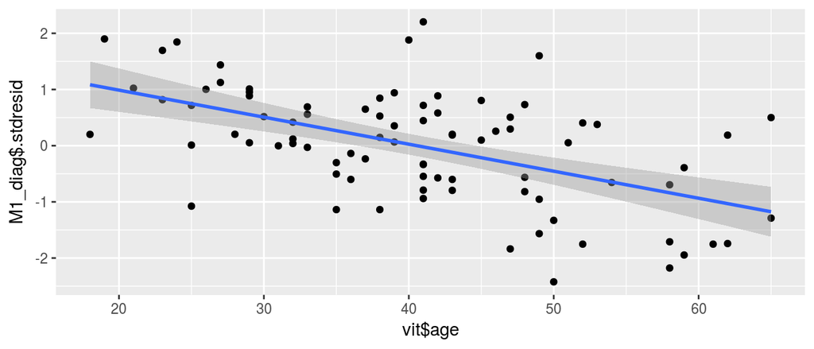

```r
M1_diag <- fortify(M1)
qplot(vit$age, M1_diag$.stdresid) + geom_smooth(method = "lm")
```

Очевидный паттерн в остатках!

Необходимо включать еще одну переменную - **`ковариату`**

## Analysis of covariance (ANCOVA)

## Меняем модель

```r
M3 <- lm(vital.capacity ~ Group + age, data = vit)
```

## Диагностика модели

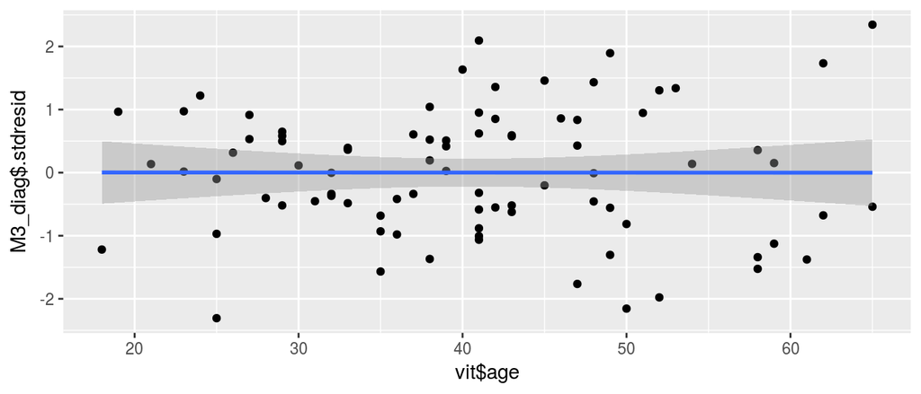

```r
M3_diag <- fortify(M3)
qplot(vit$age, M3_diag$.stdresid) + geom_smooth(method = "lm")
```

Паттерн исчез!

## Результаты

```r
summary(M3)
```

```
##
## Call:
## lm(formula = vital.capacity ~ Group + age, data = vit)
##
## Residuals:
##     Min      1Q  Median      3Q     Max
## -1.3805 -0.3805  0.0132  0.3791  1.3705
##
## Coefficients:
##                    Estimate Std. Error t value    Pr(>|t|)
## (Intercept)         5.92798    0.36086   16.43     < 2e-16 ***
## GroupNot exposed    0.11693    0.20924    0.56        0.58
## GroupShort exposed  0.04674    0.22454    0.21        0.84
## age                -0.03978    0.00632   -6.29 0.000000016 ***
## ---
## Signif. codes:  0 '***' 0.001 '**' 0.01 '*' 0.05 '.' 0.1 ' ' 1
##
## Residual standard error: 0.613 on 80 degrees of freedom
## Multiple R-squared:  0.37,   Adjusted R-squared:  0.346
## F-statistic: 15.6 on 3 and 80 DF,  p-value: 0.0000000432
```

## Результаты

```r
anova(M3)
```

```
## Analysis of Variance Table
##
## Response: vital.capacity
##           Df Sum Sq Mean Sq F value      Pr(>F)
## Group      2   2.75    1.37    3.66        0.03 *
## age        1  14.86   14.86   39.58 0.000000016 ***
## Residuals 80  30.03    0.38
## ---
## Signif. codes:  0 '***' 0.001 '**' 0.01 '*' 0.05 '.' 0.1 ' ' 1
```

Противоречие с результатами `summary()`!

## Поменяем порядок предикторов

```r
anova(lm(formula = vital.capacity ~ age + Group, data = vit))
```

```
## Analysis of Variance Table
##
## Response: vital.capacity
##           Df Sum Sq Mean Sq F value       Pr(>F)
## age        1  17.44   17.44   46.47 0.0000000016 ***
## Group      2   0.16    0.08    0.22         0.81
## Residuals 80  30.03    0.38
## ---
## Signif. codes:  0 '***' 0.001 '**' 0.01 '*' 0.05 '.' 0.1 ' ' 1
```

` Результат тестирования зависит от порядка предикторов. Почему?

## Два варианта тестирования

- Последовательное
- Иерархическое

## Вариант 1. Последовательное тестирование (SS type I)

Факторы тестируются в порядке включения в модель. Результат тестирования зависит от порядка включения.

```r
anova(lm(formula = vital.capacity ~ Group + age, data = vit))
```

```
## Analysis of Variance Table
##
## Response: vital.capacity
##           Df Sum Sq Mean Sq F value      Pr(>F)
## Group      2   2.75    1.37    3.66        0.03 *
## age        1  14.86   14.86   39.58 0.000000016 ***
## Residuals 80  30.03    0.38
## ---
## Signif. codes:  0 '***' 0.001 '**' 0.01 '*' 0.05 '.' 0.1 ' ' 1
```

- Тот предиктор, который интересует исследователия надо поставить на второе место. Влияние этого фактора тестируется после удаления влияния ковариат.

## Вариант 2. Иерархическое тестирование (SS type III)

Каждый из факторов по отношению к модели только без него, но со всеми остальными. Нужно, если много факторов и выборки разного размера. Тогда результат не будет зависеть от порядка включения факторов в модель.

```r
library(car)
Anova(M3, type = 3)
```

```
## Anova Table (Type III tests)
##
## Response: vital.capacity
##             Sum Sq Df F value      Pr(>F)
## (Intercept)  101.3  1  269.85     < 2e-16 ***
## Group          0.2  2    0.22        0.81
## age           14.9  1   39.58 0.000000016 ***
## Residuals     30.0 80
## ---
## Signif. codes:  0 '***' 0.001 '**' 0.01 '*' 0.05 '.' 0.1 ' ' 1
```

## ANCOVA на примере данных о влиянии глистогонных на рост коз

## Глистогонные и рост коз

Как влияет на прирост массы коз интенсивность профилактики паразитарных заболеваний?

Известно, что у легких животных привес больше, поэтому мы должны учитывать в модели не только способ обработки от глистов, но и влияние начального веса.

- `Treatment` - обработка от глистов (стандартная, интенсивная)
- `Weightgain` - привес, кг
- `Initial.wt` - начальный вес, кг

Пример из библиотеки данных http://www.statlab.uni-heidelberg.de/data/ancova/goats.story.html

## Читаем данные и знакомимся с ними

```r
library(readxl)
goat <- read_excel("data/goats.xlsx", sheet = 1)
head(goat)
```

```
## # A tibble: 6 × 3
##   Treatment Weightgain `Initial wt`
##       <chr>      <dbl>        <dbl>
## 1  standard          5           21
## 2  standard          3           24
## 3  standard          8           21
## 4  standard          7           22
## 5  standard          6           23
## 6  standard          4           26
```

```r
str(goat)
```

```
## Classes 'tbl_df', 'tbl' and 'data.frame':    40 obs. of  3 variables:
##  $ Treatment : chr  "standard" "standard" "standard" "standard" ...
##  $ Weightgain: num  5 3 8 7 6 4 8 6 7 5 ...
##  $ Initial wt: num  21 24 21 22 23 26 22 23 24 20 ...
```

## Читаем данные и знакомимся с ними

```r
colSums(is.na(goat))
```

```
##  Treatment Weightgain Initial wt
##          0          0          0
```

```r
# переименуем переменные для краткости
colnames(goat) <- c("treat", "wt", "init")
# объемы выборок
table(goat$treat)
```

```
##
## intensive  standard
##        20        20
```

```r
# зададим порядок уровней фактора для удобства интерпретации
goat$treat <- factor(goat$treat, levels = c("standard", "intensive"))
```

## Есть ли выбросы?

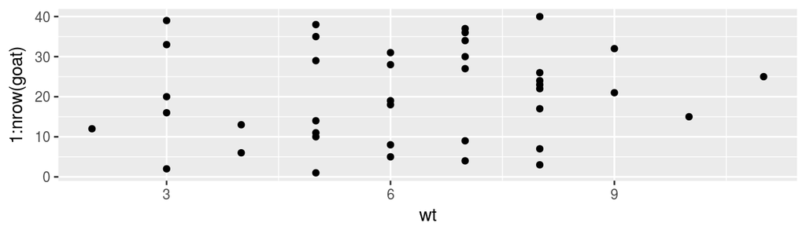

```r
library(ggplot2)
gg_dot <- ggplot(goat, aes(y = 1:nrow(goat))) + geom_point()
gg_dot + aes(x = wt)
```

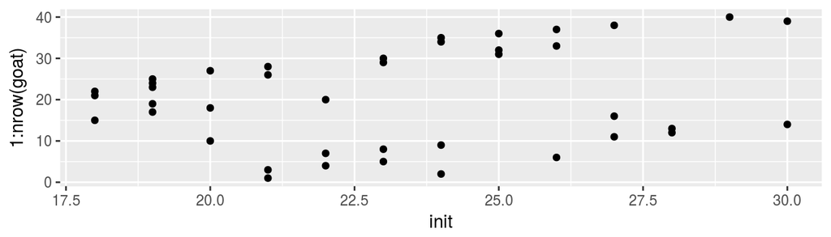

```r
gg_dot + aes(x = init)
```

## Задание

- Подберите модель, описывающую зависимость между увеличением веса коз и способом прфилактической обработки животных
- Проверьте условия применимости этой модели
- Упростите модель, если это возможно
- Проверьте условия применимости финальной модели
- Напишите общее уравнение и отдельные уравнения модели для двух способов профилактики
- Постройте график предсказаний модели

## Решение

### Нет ли колинеарности между начальным весом и тритментом

```r
MG <- lm(wt ~ init + treat, data = goat)
vif(MG)
```

```
##  init treat
##     1     1
```

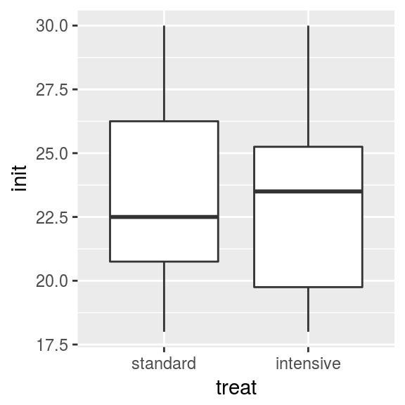

```r
ggplot(goat, aes(x = treat, y = init)) + geom_boxplot()
```

Выраженной коллинеарности нет

## Результаты

```r
summary(MG)
```

```
##
## Call:
## lm(formula = wt ~ init + treat, data = goat)
##
## Residuals:
##    Min     1Q Median     3Q    Max
## -2.972 -1.242 -0.034  0.988  3.223
##
## Coefficients:
##                Estimate Std. Error t value     Pr(>|t|)
## (Intercept)     13.7017     1.7599    7.79 0.0000000026 ***
## init            -0.3514     0.0742   -4.73 0.0000320779 ***
## treatintensive   1.2649     0.5117    2.47        0.018 *
## ---
## Signif. codes:  0 '***' 0.001 '**' 0.01 '*' 0.05 '.' 0.1 ' ' 1
##
## Residual standard error: 1.62 on 37 degrees of freedom
## Multiple R-squared:  0.438,  Adjusted R-squared:  0.408
## F-statistic: 14.4 on 2 and 37 DF,  p-value: 0.0000233
```

## Результаты

```r
anova(MG)
```

```
## Analysis of Variance Table
##
## Response: wt
##           Df Sum Sq Mean Sq F value   Pr(>F)
## init       1   59.5    59.5   22.75 0.000029 ***
## treat      1   16.0    16.0    6.11    0.018 *
## Residuals 37   96.9     2.6
## ---
## Signif. codes:  0 '***' 0.001 '**' 0.01 '*' 0.05 '.' 0.1 ' ' 1
```

## Результаты

```r
library(car)
Anova(MG, type = 3)
```

```
## Anova Table (Type III tests)
##
## Response: wt
##             Sum Sq Df F value       Pr(>F)
## (Intercept)  158.7  1   60.62 0.0000000026 ***
## init          58.6  1   22.40 0.0000320779 ***
## treat         16.0  1    6.11        0.018 *
## Residuals     96.9 37
## ---
## Signif. codes:  0 '***' 0.001 '**' 0.01 '*' 0.05 '.' 0.1 ' ' 1
```

## График модели

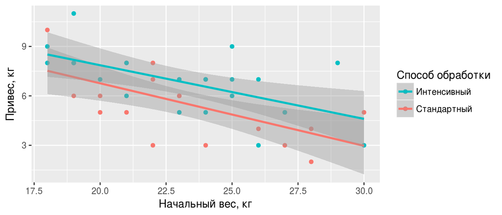

```r
gg_g <- ggplot(data = goat, aes(y = wt, x = init, colour = treat)) +
  geom_point()  +
  labs(x = "Начальный вес, кг",
       y = "Привес, кг") +
  scale_colour_discrete("Способ обработки",
                        breaks = c("intensive", "standard"),
                        labels = c("Интенсивный", "Стандартный"))
gg_g + geom_smooth(method = "lm")
```

## Решение

### Проверяем условия применимости

- Все нормально

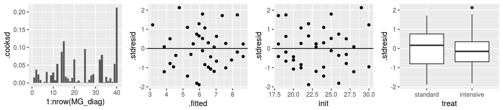

## Нормальнсть распределения остатков

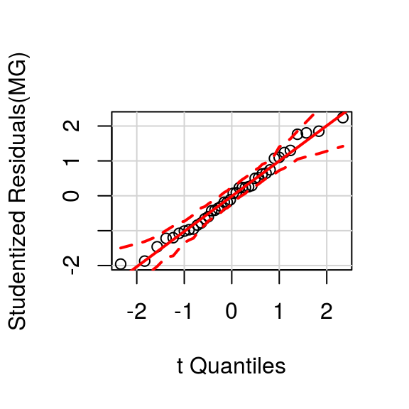

## Записываем уравнение модели

```r
coef(MG)
```

```
##    (Intercept)           init treatintensive
##         13.702         -0.351          1.265
```

Уравнение:

\(wt = 13.70 - 0.35init + 1.26treatintensive\)

Привес коз при интенсивной обработке от глистов на 1.26 кг выше, чем при стандартном методе обработки (t-тест, p < 0.05)

## Take home messages

- Нет разницы между моделями с дискретными и непрерывными предикторами
- При анализе влияния дискретного фактора часто необходимо учитывать влияние ковариаты.
- Пр тестировании гипотезы надо помнить о существовании двух типов тестирования: последовательное vs иерархическое.

## Что почитать

- Must read paper! Zuur, A.F. and Ieno, E.N., 2016. A protocol for conducting and presenting results of regression‐type analyses. Methods in Ecology and Evolution, 7(6), pp.636-645.
- Кабаков Р.И. R в действии. Анализ и визуализация данных на языке R. М.: ДМК Пресс, 2014
- Zuur, A., Ieno, E.N. and Smith, G.M., 2007. Analyzing ecological data. Springer Science & Business Media.
- Quinn G.P., Keough M.J. 2002. Experimental design and data analysis for biologists
- Logan M. 2010. Biostatistical Design and Analysis Using R. A Practical Guide